# Manage variable sets in HCP Terraform

HCP Terraform variable sets let you reuse variables in an efficient and centralized way, so you can set variable values once and use them in multiple workspaces. When you update the values, the changes automatically affect all associated workspaces, making it easier to update credentials and infrastructure settings. HCP Terraform also lets you override variables defined in variable sets on a per-workspace basis, which lets you modify the workspace's configuration without affecting other workspaces that use the variable set.

In this tutorial, you will manage multiple HCP Terraform variable sets. You will define variable sets for your AWS credentials and DynamoDB configuration. You will also review variable precedence between duplicated variables across variable sets, and between variables in variable sets and workspace-specific variables.

## Prerequisites

This tutorial assumes that you are familiar with HCP Terraform and the standard Terraform workflow. If you are new to Terraform, complete the Get Started tutorials first. If you are new to HCP Terraform, complete the HCP Terraform Get Started tutorials first.

For this tutorial, you will need:

- an [HCP Terraform account](https://app.terraform.io/public/signup/account?utm_source=learn) and organization
- Terraform v0.15+ installed locally and configured with your HCP Terraform token
- an [AWS account](https://portal.aws.amazon.com/billing/signup?nc2=h_ct&src=default&redirect_url=https%3A%2F%2Faws.amazon.com%2Fregistration-confirmation#/start)

## Clone example configuration

First, clone the [example repository](https://github.com/hashicorp-education/learn-terraform-variable-sets). This repository contains example configuration to create AWS DynamoDB tables in two environments.

```
$ git clone https://github.com/hashicorp-education/learn-terraform-variable-sets
```

Now, change into the repository directory.

```
$ cd learn-terraform-variable-sets
```

This repository contains two subdirectories:

```
$ tree
.
├── README.md
├── dev
│   ├── main.tf
│   ├── variables.tf
│   └── versions.tf
└── staging
    ├── main.tf
    ├── variables.tf
    └── versions.tf
```

The `dev` and `staging` directories each contain Terraform configuration that defines a DynamoDB table and configures it using input variables. The configuration uses the `random_pet` resource to ensure a unique name for the table, and configures the DynamoDB table using the `db_read_capacity` and `db_write_capacity` input variables.

## Initialize configuration

Navigate to the `dev` directory.

```
$ cd dev
```

Open `versions.tf` in your code editor, and replace `<ORGANIZATION_NAME>` in the `cloud` block with your own HCP Terraform organization name.

dev/versions.tf

```
terraform {

  cloud {
    organization = "<ORGANIZATION_NAME>"

    workspaces {
      name = "learn-terraform-variable-sets-dev"
    }
  }
###
```

Notice that this configuration uses the `learn-terraform-variable-sets-dev` workspace.

Initialize the configuration, which will also create the workspace in HCP Terraform.

```
$ terraform init

Initializing HCP Terraform...

Initializing provider plugins...
Reusing previous version of hashicorp/random from the dependency lock file
- Reusing previous version of hashicorp/aws from the dependency lock file
- Installing hashicorp/random v3.1.0...
- Installed hashicorp/random v3.1.0 (signed by HashiCorp)
- Installing hashicorp/aws v3.63.0...
- Installed hashicorp/aws v3.63.0 (signed by HashiCorp)

HCP Terraform has been successfully initialized!

You may now begin working with HCP Terraform. Try running "terraform plan" to
see any changes that are required for your infrastructure.

If you ever set or change modules or Terraform Settings, run "terraform init"
again to reinitialize your working directory.
```

Now, navigate to the `staging` directory.

```
$ cd ../staging
```

Open `versions.tf` in your code editor, and replace `<ORGANIZATION_NAME>` in the `cloud` block with your own HCP Terraform organization name.

staging/versions.tf

```
terraform {

  cloud {
    organization = "<ORGANIZATION_NAME>"

    workspaces {
      name = "learn-terraform-variable-sets-staging"
    }
  }
###
```

This configuration uses a different workspace, `learn-terraform-variable-sets-staging`.

Initialize the configuration, which will also create the workspace in HCP Terraform.

```
$ terraform init

Initializing HCP Terraform...

Initializing provider plugins...
Reusing previous version of hashicorp/random from the dependency lock file
- Reusing previous version of hashicorp/aws from the dependency lock file
- Installing hashicorp/random v3.1.0...
- Installed hashicorp/random v3.1.0 (signed by HashiCorp)
- Installing hashicorp/aws v3.63.0...
- Installed hashicorp/aws v3.63.0 (signed by HashiCorp)

HCP Terraform has been successfully initialized!

You may now begin working with HCP Terraform. Try running "terraform plan" to
see any changes that are required for your infrastructure.

If you ever set or change modules or Terraform Settings, run "terraform init"
again to reinitialize your working directory.
```

You now have two HCP Terraform workspaces configured for the CLI-driven workflow with remote execution.

## Create variable sets

HCP Terraform variable sets are groups of reusable variables created at the organization level. A variable set can have one of three scopes:

- **Global**: It will apply to all current and future workspaces within an organization.
- **Project-specific**: It will apply to all current and future workspaces within the selected projects.
- **Workspace-specific**: It will apply only to the selected workspaces.

Using broader variable set scope enables self-service workflows. For instance, you can create a variable set and apply it to a team-specific project, then grant the team permission to create workspaces within the project. Future workspaces will automatically inherit the variable set without requiring additional work or approval. However, we recommend scoping variable sets that contain credentials as narrowly as possible, to avoid granting access to teams or workspaces that do not need them.

### Create a credentials variable set

First, navigate to your organization's settings by clicking **Settings** in the left navigation. Then, select **Variable Sets**.

Note

If you already have a variable set for your AWS provider credentials, skip to the next section.

Click **Create variable set**.

[figure not shown]

Name this first variable set `AWS credentials`.

Warning

When possible, apply credential variable sets to specific projects or workspaces. Avoid global access and follow the principle of least privilege.

Scroll down to the **Variable set scope** section and select **Apply to specific projects and workspaces**. Select the `learn-terraform-variable-sets-dev` and `learn-terraform-variable-sets-staging` workspaces.

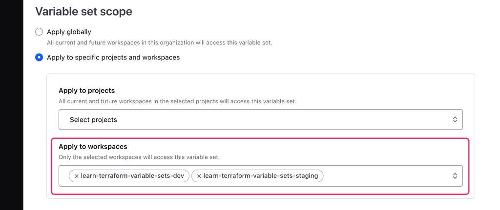

Click **+Add Variable**. Define an environment variable named `AWS_ACCESS_KEY_ID` and set it to your AWS Access Key ID. Mark it as sensitive and click **Save variable**.

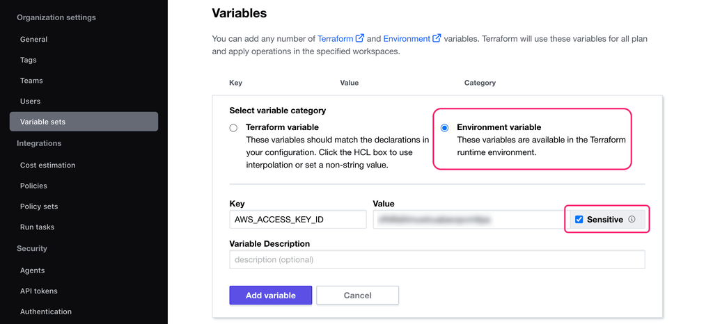

Then, click **+Add Variable** again. Define another environment variable named `AWS_SECRET_ACCESS_KEY` and set it to your AWS Secret access key. Mark it as sensitive and click **Save variable**.

Tip

If you have temporary AWS credentials, you must also add your `AWS_SESSION_TOKEN` as an environment variable.

Finally, click **Create variable set**.

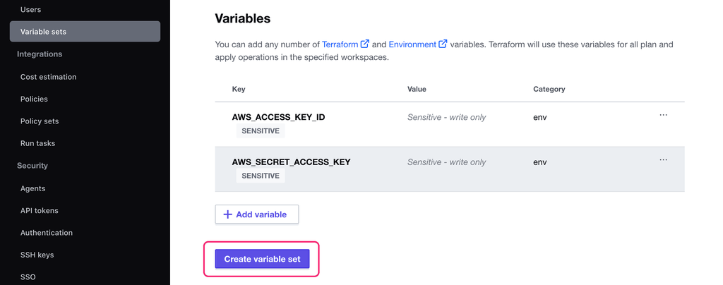

### Create configuration settings variable set

You can also use variable sets to define reusable input variables. In this scenario, you will provision DynamoDB tables for two environments, `dev` and `staging`. Use a variable set to define the read and write capacities for both.

Create another variable set named `Default DynamoDB settings`. Once again, apply it to both the `learn-terraform-variable-sets-dev` and `learn-terraform-variable-sets-staging` workspaces.

Define two Terraform variables in the variable set:

1. A **Terraform variable** named `db_write_capacity` with a value of `1`.
2. A **Terraform variable** named `db_read_capacity` with a value of `1`.

Save the variable set.

Rather than individually defining the database read and write capacity in both workspaces, you were able to just define them once as a variable set and apply them to the workspaces that need them.

## Review workspace variables

You can review and manage which variable sets apply to the workspace from the workspace itself.

Navigate to your `learn-terraform-variable-sets-dev` workspace, then select the **Variables** tab.

Under **Variable sets**, the workspace lists both your `AWS credentials` and `Default DynamoDB settings` variable sets and the variables that they contain.

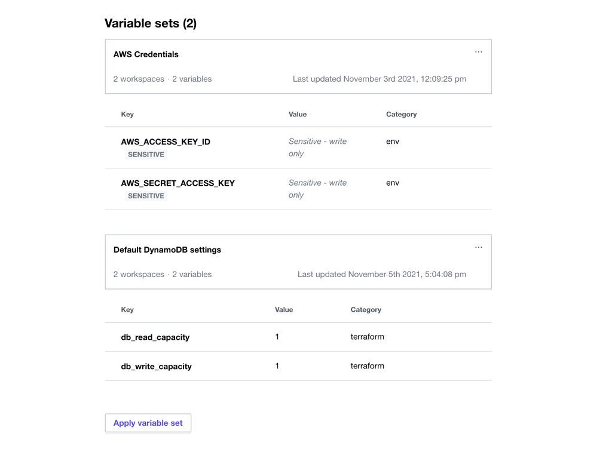

## Apply configuration

In your terminal, navigate to your `learn-terraform-variable-sets/dev` directory.

You already initialized your configuration earlier, so now apply it. Respond `yes` when prompted to confirm the operation.

```
$ terraform apply
Running apply in HCP Terraform. Output will stream here. Pressing Ctrl-C
will cancel the remote apply if it's still pending. If the apply started it
will stop streaming the logs, but will not stop the apply running remotely.

Preparing the remote apply...

To view this run in a browser, visit:
https://app.terraform.io/app/hashicorp-training/learn-terraform-variable-sets-dev/runs/run-fRjkg53BhhhwbEUN

Waiting for the plan to start...

Terraform v1.0.7
on linux_amd64
Configuring remote state backend...
Initializing Terraform configuration...

Terraform used the selected providers to generate the following execution
plan. Resource actions are indicated with the following symbols:
  + create

Terraform will perform the following actions:
##...
Plan: 2 to add, 0 to change, 0 to destroy.

Do you want to perform these actions in workspace "learn-terraform-variable-sets-dev"?
  Terraform will perform the actions described above.
  Only 'yes' will be accepted to approve.

  Enter a value: yes

random_pet.table_name: Creating...
random_pet.table_name: Creation complete after 0s [id=still-pony]
aws_dynamodb_table.table: Creating...
aws_dynamodb_table.table: Creation complete after 4s [id=dev-still-pony]

Apply complete! Resources: 2 added, 0 changed, 0 destroyed.
```

Go to the `learn-terraform-variable-sets-dev` workspace to find the resources it manages.

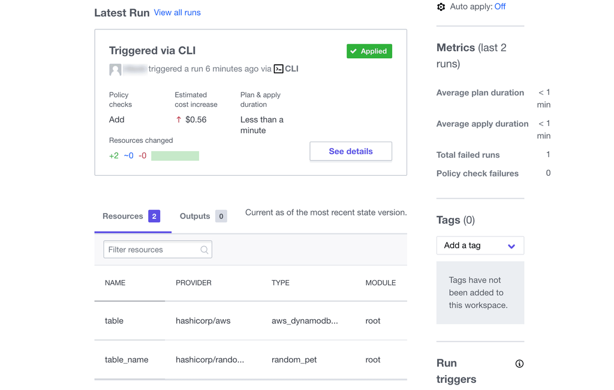

Now, navigate to your `staging` directory.

```
$ cd ../staging
```

Apply your configuration. Respond `yes` when prompted to confirm the operation.

```
$ terraform apply
Running apply in HCP Terraform. Output will stream here. Pressing Ctrl-C
will cancel the remote apply if it's still pending. If the apply started it
will stop streaming the logs, but will not stop the apply running remotely.

Preparing the remote apply...

To view this run in a browser, visit:
https://app.terraform.io/app/hashicorp-training/learn-terraform-variable-sets-staging/runs/run-WMTfEG5hFmwaNArq

Waiting for the plan to start...

Terraform v1.0.7
on linux_amd64
Configuring remote state backend...
Initializing Terraform configuration...

Terraform used the selected providers to generate the following execution
plan. Resource actions are indicated with the following symbols:
  + create

Terraform will perform the following actions:
##...
Plan: 2 to add, 0 to change, 0 to destroy.

Do you want to perform these actions in workspace "learn-terraform-variable-sets-staging"?
  Terraform will perform the actions described above.
  Only 'yes' will be accepted to approve.

  Enter a value: yes

random_pet.table_name: Creating...
random_pet.table_name: Creation complete after 0s [id=guiding-kite]
aws_dynamodb_table.table: Creating...
aws_dynamodb_table.table: Creation complete after 7s [id=staging-guiding-kite]

Apply complete! Resources: 2 added, 0 changed, 0 destroyed.
```

## Explore variable set precedence

If any of the variable sets associated with the workspace contain a variable of the same type (input or environment variables) with the same name, HCP Terraform will use lexical order to determine variable precedence.

In this scenario, you applied a default set of DynamoDB settings to both tables. While you generally want to use consistent settings across both resources, you may want to perform load testing on one of your tables.

Navigate back to the variable sets page in your organization settings, create a new variable set named `Add Capacity - DynamoDB load testing`, and apply it to the `learn-terraform-variable-sets-staging` workspace.

Create two Terraform variables for this variable set:

1. Set `db_write_capacity` to `10`
2. Set `db_read_capacity` to `10`

Save your new variable set.

Now, navigate back to your `learn-terraform-variable-sets-staging` workspace and navigate to the **Variables** page. It lists 3 variable sets applying to your workspace.

Scroll down to find the `Default DynamoDB settings` variable set, which shows its values as overwritten.

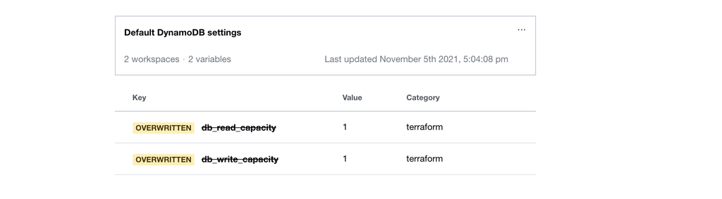

Both your default and load testing variable sets define variables named `db_write_capacity` and `db_read_capacity`. Since the load testing variable set name begins with the letter "A", that variable set took precedence over your default settings. If you want HCP Terraform to use the default DynamoDB variable set instead, you can:

- change the names of the variable sets so that the default set has lexical precedence over the load testing set, or
- remove the load testing variable set from the workspace.

In your terminal, run `terraform apply` in your `staging` directory to update your table's configuration. Respond `yes` when prompted to confirm the operation.

```
$ terraform apply
Running apply in HCP Terraform. Output will stream here. Pressing Ctrl-C
will cancel the remote apply if it's still pending. If the apply started it
will stop streaming the logs, but will not stop the apply running remotely.

Preparing the remote apply...

To view this run in a browser, visit:
https://app.terraform.io/app/hashicorp-training/learn-terraform-variable-sets-staging/runs/run-1j7aMQm8v4HdMWMR

Waiting for the plan to start...

Terraform v1.0.7
on linux_amd64
Configuring remote state backend...
Initializing Terraform configuration...
random_pet.table_name: Refreshing state... [id=guiding-kite]
aws_dynamodb_table.table: Refreshing state... [id=staging-guiding-kite]

Terraform used the selected providers to generate the following execution
plan. Resource actions are indicated with the following symbols:
  ~ update in-place

Terraform will perform the following actions:

  # aws_dynamodb_table.table will be updated in-place
  ~ resource "aws_dynamodb_table" "table" {
        id             = "staging-guiding-kite"
        name           = "staging-guiding-kite"
      ~ read_capacity  = 1 -> 10
        tags           = {}
      ~ write_capacity = 1 -> 10
        # (5 unchanged attributes hidden)

        # (3 unchanged blocks hidden)
    }

Plan: 0 to add, 1 to change, 0 to destroy.

Do you want to perform these actions in workspace "learn-terraform-variable-sets-staging"?
  Terraform will perform the actions described above.
  Only 'yes' will be accepted to approve.

  Enter a value: yes

aws_dynamodb_table.table: Modifying... [id=staging-guiding-kite]
aws_dynamodb_table.table: Modifications complete after 2s [id=staging-guiding-kite]

Apply complete! Resources: 0 added, 1 changed, 0 destroyed.
```

## Overwrite a variable in a variable set

You can also overwrite a variable defined in a variable set by creating a workspace-specific variable with the same key. HCP Terraform will always use workspace-specific variables over any variables defined in variable sets applied to the workspace.

In a load testing scenario, you may want to scale up your write capacity to test how your application's performance responds. In your `learn-terraform-variable-sets-staging` workspace, create a workspace-specific input variable named `db_write_capacity` and set the value to `15`.

HCP Terraform now shows the `db_write_capacity` variable in the load testing variable set as overwritten.

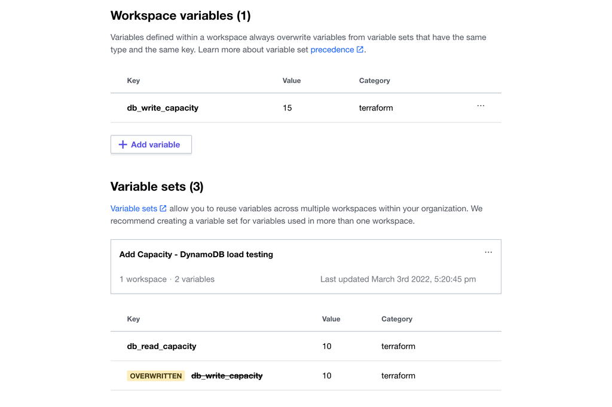

In your terminal, run a `terraform apply` to further scale your DynamoDB table's write capacity. Respond yes to the prompt to confirm the operation.

```
$ terraform apply
Running apply in HCP Terraform. Output will stream here. Pressing Ctrl-C
will cancel the remote apply if it's still pending. If the apply started it
will stop streaming the logs, but will not stop the apply running remotely.

Preparing the remote apply...

To view this run in a browser, visit:
https://app.terraform.io/app/hashicorp-training/learn-terraform-variable-sets-staging/runs/run-H5aAbCPCZ3xKiw9j

Waiting for the plan to start...

Terraform v1.0.7
on linux_amd64
Configuring remote state backend...
Initializing Terraform configuration...
random_pet.table_name: Refreshing state... [id=guiding-kite]
aws_dynamodb_table.table: Refreshing state... [id=staging-guiding-kite]

Terraform used the selected providers to generate the following execution
plan. Resource actions are indicated with the following symbols:
  ~ update in-place

Terraform will perform the following actions:

  # aws_dynamodb_table.table will be updated in-place
  ~ resource "aws_dynamodb_table" "table" {
        id             = "staging-guiding-kite"
        name           = "staging-guiding-kite"
        tags           = {}
      ~ write_capacity = 10 -> 15
        # (6 unchanged attributes hidden)

        # (3 unchanged blocks hidden)
    }

Plan: 0 to add, 1 to change, 0 to destroy.

Do you want to perform these actions in workspace "learn-terraform-variable-sets-staging"?
  Terraform will perform the actions described above.
  Only 'yes' will be accepted to approve.

  Enter a value: yes

aws_dynamodb_table.table: Modifying... [id=staging-guiding-kite]
aws_dynamodb_table.table: Modifications complete after 3s [id=staging-guiding-kite]

Apply complete! Resources: 0 added, 1 changed, 0 destroyed.
```

Since you set a workspace-specific variable for the write capacity, HCP Terraform prioritized that value and scaled your table's write capacity to 15, overwriting the variable set values.

For more information on how HCP Terraform inherits variable sets and overrides values, see [Workspace variable precedence](https://developer.hashicorp.com/terraform/cloud-docs/workspaces/variables#precedence).

## Clean up resources

In your `staging` directory, destroy the table you created. Respond `yes` when prompted to confirm the operation.

```
$ terraform destroy
Running apply in HCP Terraform. Output will stream here. Pressing Ctrl-C
will cancel the remote apply if it's still pending. If the apply started it
will stop streaming the logs, but will not stop the apply running remotely.

Preparing the remote apply...

To view this run in a browser, visit:
https://app.terraform.io/app/hashicorp-training/learn-terraform-variable-sets-staging/runs/run-W8NaRXye3gmGs1cy

Waiting for the plan to start...

Terraform v1.0.7
on linux_amd64
Configuring remote state backend...
Initializing Terraform configuration...
random_pet.table_name: Refreshing state... [id=guiding-kite]
aws_dynamodb_table.table: Refreshing state... [id=staging-guiding-kite]

Terraform used the selected providers to generate the following execution
plan. Resource actions are indicated with the following symbols:
  - destroy

Terraform will perform the following actions:
##...
Plan: 0 to add, 0 to change, 2 to destroy.

Do you really want to destroy all resources in workspace "learn-terraform-variable-sets-staging"?
  Terraform will destroy all your managed infrastructure, as shown above.
  There is no undo. Only 'yes' will be accepted to confirm.

  Enter a value: yes

aws_dynamodb_table.table: Destroying... [id=staging-guiding-kite]
aws_dynamodb_table.table: Destruction complete after 3s
random_pet.table_name: Destroying... [id=guiding-kite]
random_pet.table_name: Destruction complete after 0s

Apply complete! Resources: 0 added, 0 changed, 2 destroyed.
```

Then, change to your `dev` directory.

```
$ cd ../dev
```

Destroy the infrastructure managed in this directory as well.

```
$ terraform destroy
Running apply in HCP Terraform. Output will stream here. Pressing Ctrl-C
will cancel the remote apply if it's still pending. If the apply started it
will stop streaming the logs, but will not stop the apply running remotely.

Preparing the remote apply...

To view this run in a browser, visit:
https://app.terraform.io/app/hashicorp-training/learn-terraform-variable-sets-dev/runs/run-v3Nszw3Eybo432AH

Waiting for the plan to start...

Terraform v1.0.7
on linux_amd64
Configuring remote state backend...
Initializing Terraform configuration...
random_pet.table_name: Refreshing state... [id=still-pony]
aws_dynamodb_table.table: Refreshing state... [id=dev-still-pony]

Terraform used the selected providers to generate the following execution
plan. Resource actions are indicated with the following symbols:
  - destroy

Terraform will perform the following actions:
##...
Plan: 0 to add, 0 to change, 2 to destroy.

Do you really want to destroy all resources in workspace "learn-terraform-variable-sets-dev"?
  Terraform will destroy all your managed infrastructure, as shown above.
  There is no undo. Only 'yes' will be accepted to confirm.

  Enter a value: yes

aws_dynamodb_table.table: Destroying... [id=dev-still-pony]
aws_dynamodb_table.table: Destruction complete after 3s
random_pet.table_name: Destroying... [id=still-pony]
random_pet.table_name: Destruction complete after 0s

Apply complete! Resources: 0 added, 0 changed, 2 destroyed.
```

### Clean up HCP Terraform resources

Then, navigate to your `learn-terraform-variable-sets-dev` workspace in HCP Terraform and delete the workspace.

Now, navigate to your `learn-terraform-variable-sets-staging` workspace and delete the workspace.

Finally, navigate to your variable sets list under the organization settings. Delete your `Default DynamoDB settings` variable set by clicking on it, scrolling to the bottom, and clicking **Delete variable set**.

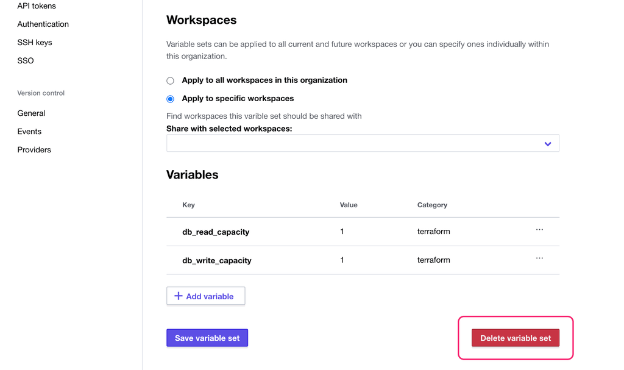

Delete your load testing variable set, and optionally your AWS credentials variable set as well.

## Next steps

In this tutorial, you learned how to create and use variable sets to manage your HCP Terraform workspace's input and environment variables. You also learned about variable precedence between variable sets and how to overwrite variables within a workspace.

Check out the following resources to learn more about HCP Terraform configuration options and features:

- Connect multiple workspaces with run triggers
- Use Vault to generate scoped, short-lived credentials for AWS
- Organize workspaces with projects